# Does Container Type Affect Perceived Soda Taste?

- Show All Code
- Hide All Code
- View Source

A Randomized Complete Block Design Analysis

Author

Bradley Petersen

## Overview

This project examines whether the type of container used to serve soda is associated with differences in perceived **taste/crispness ratings**. The data contain three container treatments—**Glass Bottle**, **Can**, and **Plastic Cup**—observed across four blocks with three replicates per block-treatment combination.

The analysis uses a **randomized complete block design (RCBD)** framework to estimate the treatment effect while accounting for block-to-block variation. In addition to the primary ANOVA, the project includes exploratory visualization, descriptive statistics, model diagnostics, and Bonferroni-adjusted pairwise comparisons.

The data was collected by four experimenters, each of whom randomly selected three participants. Each participant received all three treatments in a randomly generated order.

### Research question

> After accounting for block effects, is there evidence that mean taste/crispness ratings differ among glass bottles, cans, and plastic cups?

### Statistical hypotheses

- **Null hypothesis:** Mean taste/crispness rating is the same for all three container treatments.
- **Alternative hypothesis:** At least one treatment mean differs.
- **Significance level:** $\alpha = 0.05$.

## Data

The dataset contains 36 observations: 4 blocks × 3 treatments × 3 replicates.

```r
soda_data <- read.csv("raw_soda_data.csv")

soda_data$block <- factor(soda_data$block)
soda_data$treatment <- factor(soda_data$treatment)
soda_data$replicate <- factor(soda_data$replicate)
```

```r
knitr::kable(
  head(soda_data, 10),
  caption = "First 10 observations in the dataset"
)
```

First 10 observations in the dataset

| block | treatment | taste_score | replicate |
| --- | --- | --- | --- |
| Block1 | Glass Bottle | 8 | 1 |
| Block1 | Can | 9 | 1 |
| Block1 | Plastic Cup | 7 | 1 |
| Block2 | Glass Bottle | 4 | 1 |
| Block2 | Can | 8 | 1 |
| Block2 | Plastic Cup | 9 | 1 |
| Block3 | Glass Bottle | 7 | 1 |
| Block3 | Can | 9 | 1 |
| Block3 | Plastic Cup | 4 | 1 |
| Block4 | Glass Bottle | 7 | 1 |

### Design balance

A balanced design is useful because each block-treatment combination contributes equally to the analysis.

```r
sample_size_table <- table(soda_data$block, soda_data$treatment)
knitr::kable(sample_size_table, caption = "Observations per block-treatment combination")
```

Observations per block-treatment combination

|  | Can | Glass Bottle | Plastic Cup |
| --- | --- | --- | --- |
| Block1 | 3 | 3 | 3 |
| Block2 | 3 | 3 | 3 |
| Block3 | 3 | 3 | 3 |
| Block4 | 3 | 3 | 3 |

## Exploratory analysis

### Descriptive statistics

```r
mean_sd <- function(x) {
  c(n = length(x), mean = mean(x), sd = sd(x))
}

summary_by_treatment <- aggregate(
  taste_score ~ treatment,
  data = soda_data,
  FUN = mean_sd
)

summary_by_treatment <- do.call(data.frame, summary_by_treatment)
names(summary_by_treatment) <- c("Treatment", "n", "Mean", "SD")
summary_by_treatment$Mean <- round(summary_by_treatment$Mean, 2)
summary_by_treatment$SD <- round(summary_by_treatment$SD, 2)

knitr::kable(
  summary_by_treatment,
  caption = "Taste/crispness ratings by container treatment"
)
```

Taste/crispness ratings by container treatment

| Treatment | n | Mean | SD |
| --- | --- | --- | --- |
| Can | 12 | 7.58 | 1.56 |
| Glass Bottle | 12 | 6.92 | 1.56 |
| Plastic Cup | 12 | 6.67 | 1.78 |

The **Can** treatment has the highest observed mean rating (7.58), followed by **Glass Bottle** (6.92) and **Plastic Cup** (6.67). These descriptive differences do not by themselves establish a statistically significant treatment effect.

### Distribution by treatment

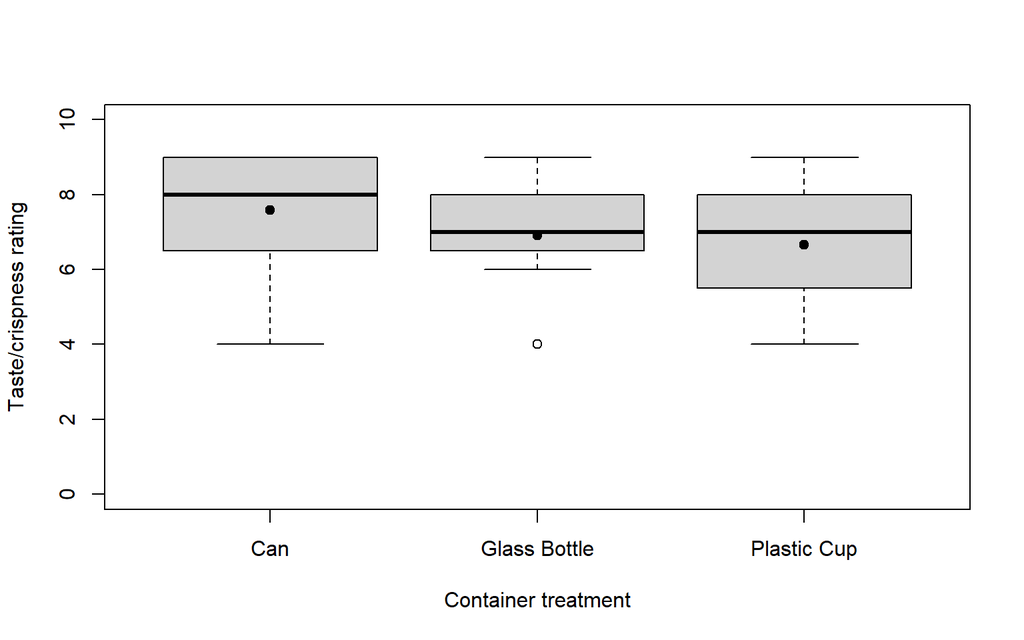

Figure 1: Distribution of taste/crispness ratings by container treatment. Black points indicate treatment means.

```r
boxplot(
  taste_score ~ treatment,
  data = soda_data,
  xlab = "Container treatment",
  ylab = "Taste/crispness rating",
  ylim = c(0, 10)
)

points(
  seq_along(levels(soda_data$treatment)),
  tapply(soda_data$taste_score, soda_data$treatment, mean),
  pch = 19
)
```

### Treatment patterns across blocks

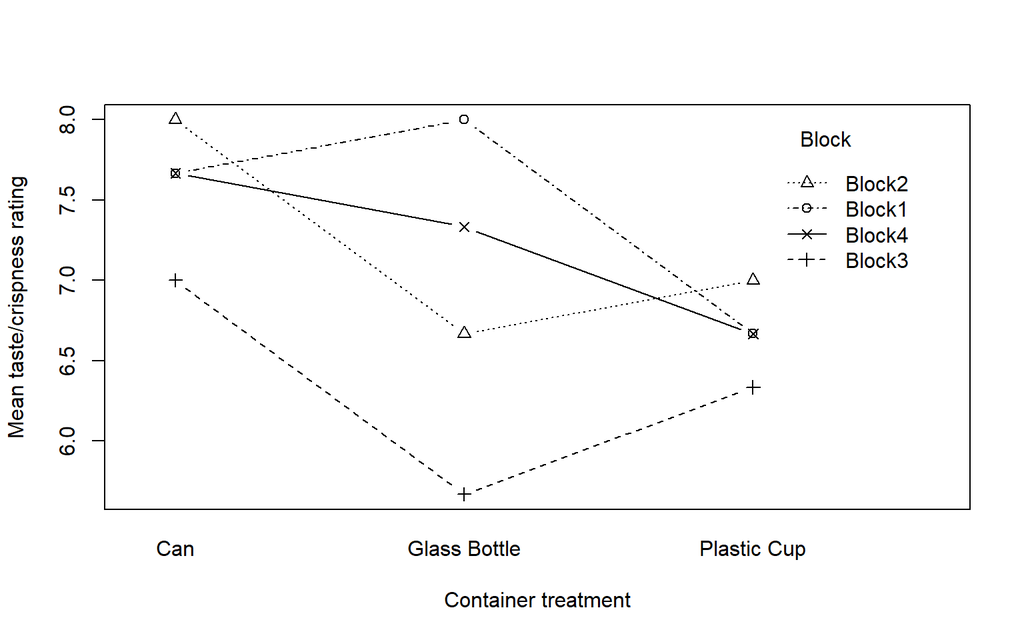

Figure 2: Mean treatment ratings within each block.

```r
interaction.plot(
  x.factor = soda_data$treatment,
  trace.factor = soda_data$block,
  response = soda_data$taste_score,
  fun = mean,
  type = "b",
  pch = 1:4,
  xlab = "Container treatment",
  ylab = "Mean taste/crispness rating",
  trace.label = "Block"
)
```

## Statistical model

The RCBD model is

$$Y_{ij} = \mu + \beta_i + \tau_j + \varepsilon_{ij},$$

where $\mu$ is the overall mean, $\beta_i$ is the effect of block $i$, $\tau_j$ is the effect of container treatment $j$, and $\varepsilon_{ij}$ represents random error.

```r
rcbd_model <- aov(taste_score ~ block + treatment, data = soda_data)
anova_table <- anova(rcbd_model)

anova_display <- data.frame(
  Source = rownames(anova_table),
  Df = anova_table[, "Df"],
  `Sum Sq` = round(anova_table[, "Sum Sq"], 3),
  `Mean Sq` = round(anova_table[, "Mean Sq"], 3),
  `F value` = round(anova_table[, "F value"], 3),
  `p-value` = round(anova_table[, "Pr(>F)"], 4),
  check.names = FALSE
)

knitr::kable(anova_display, caption = "RCBD ANOVA results")
```

RCBD ANOVA results

| Source | Df | Sum Sq | Mean Sq | F value | p-value |
| --- | --- | --- | --- | --- | --- |
| block | 3 | 6.556 | 2.185 | 0.800 | 0.5037 |
| treatment | 2 | 5.389 | 2.694 | 0.986 | 0.3847 |
| Residuals | 30 | 81.944 | 2.731 | NA | NA |

### Primary result

In this dataset, there is **insufficient evidence that mean taste/crispness ratings differ by container type after accounting for block effects**. Although cans produced the highest observed mean rating, the difference was not large enough relative to within-treatment variability to support a statistically significant treatment effect.

## Model diagnostics

Model assumptions were evaluated using residual plots, a normal Q-Q plot, and a Bartlett test for equal variances across treatments.

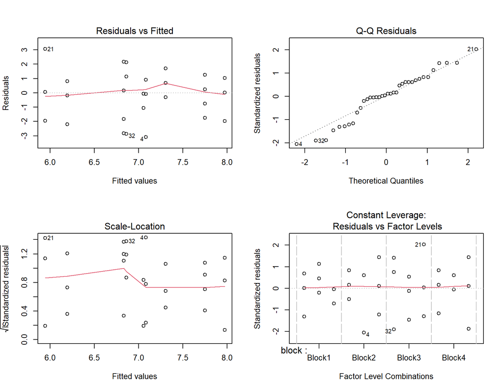

Figure 3: Standard diagnostic plots for the RCBD ANOVA model.

```r
oldpar <- par(no.readonly = TRUE)
par(mfrow = c(2, 2))
plot(rcbd_model)
par(oldpar)
```

### Equal-variance check

```r
bartlett_treatment <- bartlett.test(taste_score ~ treatment, data = soda_data)

bartlett_display <- data.frame(
  Statistic = round(unname(bartlett_treatment$statistic), 3),
  df = unname(bartlett_treatment$parameter),
  `p-value` = round(bartlett_treatment$p.value, 4),
  check.names = FALSE
)

knitr::kable(bartlett_display, caption = "Bartlett test for equal treatment variances")
```

Bartlett test for equal treatment variances

| Statistic | df | p-value |
| --- | --- | --- |
| 0.232 | 2 | 0.8907 |

With a Bartlett-test p-value of 0.891, the data do not provide evidence of unequal treatment variances at the 0.05 level.

## Supplementary pairwise comparisons

Because the overall treatment ANOVA is not significant, pairwise comparisons are not the basis of the primary conclusion. They are included here to demonstrate the post-ANOVA workflow and the use of a Bonferroni correction for multiple comparisons.

```r
trt_levels <- levels(soda_data$treatment)
pairs <- t(combn(trt_levels, 2))

mse <- anova_table["Residuals", "Mean Sq"]
df_error <- anova_table["Residuals", "Df"]
trt_means <- tapply(soda_data$taste_score, soda_data$treatment, mean)
trt_n <- table(soda_data$treatment)

posthoc <- data.frame(
  Comparison = paste(pairs[, 1], "vs", pairs[, 2]),
  Mean_1 = as.numeric(trt_means[pairs[, 1]]),
  Mean_2 = as.numeric(trt_means[pairs[, 2]])
)

posthoc$Difference <- posthoc$Mean_1 - posthoc$Mean_2
posthoc$SE <- sqrt(
  mse * (
    1 / as.numeric(trt_n[pairs[, 1]]) +
      1 / as.numeric(trt_n[pairs[, 2]])
  )
)
posthoc$t_value <- posthoc$Difference / posthoc$SE
posthoc$p_raw <- 2 * pt(-abs(posthoc$t_value), df = df_error)
posthoc$p_bonferroni <- pmin(posthoc$p_raw * nrow(posthoc), 1)

tcrit_bonf <- qt(1 - alpha / (2 * nrow(posthoc)), df = df_error)
posthoc$CI_low <- posthoc$Difference - tcrit_bonf * posthoc$SE
posthoc$CI_high <- posthoc$Difference + tcrit_bonf * posthoc$SE

posthoc[, 2:ncol(posthoc)] <- lapply(posthoc[, 2:ncol(posthoc)], round, 3)
knitr::kable(posthoc, caption = "Bonferroni-adjusted pairwise treatment comparisons")
```

Bonferroni-adjusted pairwise treatment comparisons

| Comparison | Mean_1 | Mean_2 | Difference | SE | t_value | p_raw | p_bonferroni | CI_low | CI_high |
| --- | --- | --- | --- | --- | --- | --- | --- | --- | --- |
| Can vs Glass Bottle | 7.583 | 6.917 | 0.667 | 0.675 | 0.988 | 0.331 | 0.993 | -1.044 | 2.378 |
| Can vs Plastic Cup | 7.583 | 6.667 | 0.917 | 0.675 | 1.359 | 0.184 | 0.553 | -0.794 | 2.628 |
| Glass Bottle vs Plastic Cup | 6.917 | 6.667 | 0.250 | 0.675 | 0.371 | 0.714 | 1.000 | -1.461 | 1.961 |

## Conclusion

This analysis found **no statistically significant evidence that container type affected perceived soda taste/crispness ratings** after accounting for block effects. The observed treatment means ranged from 6.67 to 7.58, but the RCBD ANOVA indicated that these differences were consistent with random variability in the sample.

From a data-analysis perspective, this project demonstrates a complete experimental-analysis workflow: structuring a balanced dataset, performing exploratory analysis, fitting an RCBD ANOVA model, evaluating model assumptions, conducting multiple-comparison procedures, and communicating statistical results in a reproducible Quarto report.

## Reproducibility

This report is fully reproducible from the `.qmd` file. It uses only base R plus `knitr`, which is used by Quarto to render tables.